# BRIDGE-TO-BIRTH: Postpartum Surveillance Analysis

Algorithmic Risk Scoring & Triage Validation via Synthetic Cohorts

Vani Patel

2026-05-21

# Introduction

## Clinical Context & Significance

The late postpartum window (up to one year following delivery) represents a critical structural gap in modern maternal care. According to historical data from the Centers for Disease Control and Prevention (CDC), over 80% of pregnancy-related deaths are completely preventable. A primary driver of these tragic outcomes is the delayed recognition gap—the time latency between a patient experiencing severe physiological symptoms (such as preeclampsia, sepsis, or secondary hemorrhage) and receiving definitive emergency clinical evaluation.

The BRIDGE-TO-BIRTH initiative bridges this gap by replacing reactive, clinic-dependent follow-ups with an automated, text-message-based surveillance pipeline. This document provides a reproducible biostatistical validation framework evaluating a point-based Postpartum Early Warning Score (PEWS) engine optimized for remote mobile text surveillance.

## Data Engineering & Patient Simulation

Because real-world Electronic Health Record (EHR) text responses are restricted by privacy regulations, we construct a high-fidelity synthetic cohort of 1,000 postpartum patients. Crucially, the data engine relies on joint probabilistic distribution matrices, ensuring that baseline chronic health metrics naturally elevate the likelihood of reporting severe acute clinical features.

# Algorithmic Risk-Tier Mapping

The PEWS pipeline applies a point-based integer allocation system mapped directly from clinical emergency protocols:

- Severe Headache, Visual Alterations, Fever, or Heavy Bleeding: $+3$ Points each (Critical acute emergencies)
- Extreme Postpartum Anxiety or Deep Sadness: $+2$ Points (Mental health metric)
- Baseline Co-morbidities (Age > 35, Chronic Hypertension, Preeclampsia History): $+1$ Point each

Patients are split into three operational action tiers based on their cumulative mathematical threshold:

- Red (Critical): Score $\ge 4$ OR reporting any individual 3-point critical physiological symptom.
- Yellow (Moderate): Score of 2 or 3.
- Green (Stable): Score $\le 1$.

| Patient_ID | Age_Over_35 | Chronic_HTN | History_of_Preeclampsia | Severe_Headache | Fever | Heavy_Bleeding | Extreme_Anxiety | Risk_Score | Triage_Tier |
| --- | --- | --- | --- | --- | --- | --- | --- | --- | --- |
| B2B-1001 | 0 | 1 | 1 | 0 | 0 | 0 | 0 | 2 | Yellow - Moderate |
| B2B-1002 | 0 | 0 | 0 | 0 | 0 | 0 | 0 | 0 | Green - Stable |
| B2B-1003 | 0 | 0 | 0 | 0 | 0 | 0 | 0 | 0 | Green - Stable |
| B2B-1004 | 0 | 0 | 0 | 0 | 0 | 0 | 0 | 0 | Green - Stable |
| B2B-1005 | 0 | 0 | 0 | 0 | 0 | 0 | 1 | 2 | Yellow - Moderate |
| B2B-1006 | 0 | 1 | 0 | 0 | 0 | 0 | 0 | 1 | Green - Stable |
| B2B-1007 | 0 | 1 | 0 | 0 | 0 | 0 | 0 | 1 | Green - Stable |
| B2B-1008 | 1 | 0 | 0 | 0 | 0 | 0 | 1 | 3 | Yellow - Moderate |
| B2B-1009 | 0 | 0 | 0 | 0 | 0 | 0 | 0 | 0 | Green - Stable |
| B2B-1010 | 0 | 0 | 0 | 0 | 0 | 0 | 0 | 0 | Green - Stable |

# Descriptive Cohort Stratification (Table One)

To evaluate if the algorithm appropriately partitions patients based on clinical severity, we compile a baseline clinical stratification matrix comparing patient characteristics across the discovered triage groups.

```
##                                      Stratified by Triage_Tier
##                                       Green - Stable Red - Critical
##   n                                    688            169
##   Age_Over_35 (mean (SD))             0.18 (0.38)    0.24 (0.43)
##   Chronic_HTN (mean (SD))             0.08 (0.27)    0.28 (0.45)
##   History_of_Preeclampsia (mean (SD)) 0.04 (0.20)    0.14 (0.34)
##   Severe_Headache (mean (SD))         0.00 (0.00)    0.37 (0.48)
##   Fever (mean (SD))                   0.00 (0.00)    0.31 (0.47)
##   Heavy_Bleeding (mean (SD))          0.00 (0.00)    0.33 (0.47)
##   Extreme_Anxiety (mean (SD))         0.00 (0.00)    0.16 (0.37)
##   Risk_Score (mean (SD))              0.30 (0.46)    4.02 (1.07)
##                                      Stratified by Triage_Tier
##                                       Yellow - Moderate
##   n                                    143
##   Age_Over_35 (mean (SD))             0.34 (0.47)
##   Chronic_HTN (mean (SD))             0.22 (0.42)
##   History_of_Preeclampsia (mean (SD)) 0.20 (0.40)
##   Severe_Headache (mean (SD))         0.00 (0.00)
##   Fever (mean (SD))                   0.00 (0.00)
##   Heavy_Bleeding (mean (SD))          0.00 (0.00)
##   Extreme_Anxiety (mean (SD))         0.73 (0.44)
##   Risk_Score (mean (SD))              2.22 (0.42)
```

# 1. Cumulative Risk Score Distribution by Triage Status

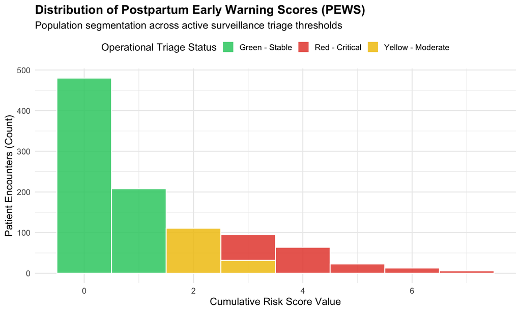

# 2. Individual Acute Symptom Prevalence across Risk Tiers

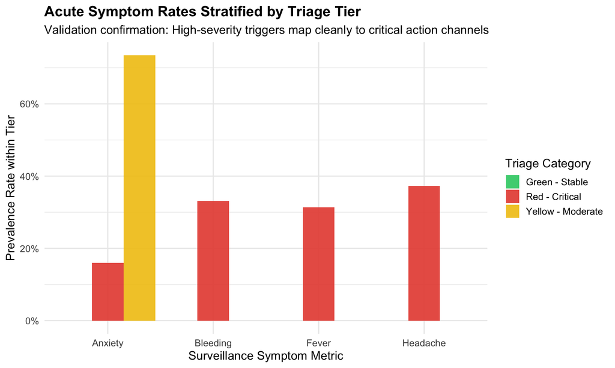

# Operational Conclusions

*Latent Risk Neutralization:*

- By utilizing dynamic joint-probability assignments, the score captures cumulative micro-risks (such as anxiety paired with a historical hypertensive background) that would normally slip under standard binary checklists.

*Resource Optimization:*

- Because the backend calculation relies completely on integer addition rules rather than iterative computations, it can execute instantaneously within any SMS gateway, making it highly scalable for under-resourced public health settings.